# R 定性数据分析作业

Li Zongzhang

2023-05-11

# 本章习题

1. 用R完成统计学(第8版)P181, 习题9.2,习题9.3。答题要求：附上R代码及输出结果。

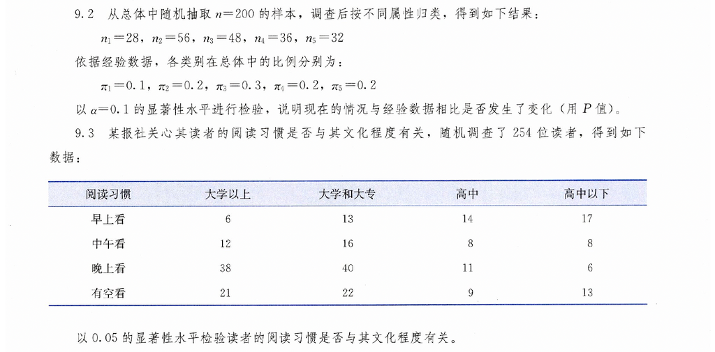

2. 数据集：titanic {ggmosaic}。提示：安装和加载包ggmosaic, 然后运行data(titanic)

   利用R完成下列要求,附上R代码及输出结果。

   2.1 对Class和Survived进行独立性检验。

   2.2 绘制Class和Survived的列联表、计算行的百分比和列的百分比。

   2.3 绘制堆栈百分比条形图呈现Class和Survived的分布，在图中标注出百分比。

   2.4 绘制马赛克图(Mosaic Plot)呈现Class和Survived的分布。

   2.5 简要概括Class和Survived二者之间关系特征。

   2.6 对Class和Sex进行独立性检验。

   2.7 绘制Class和Sex的列联表、计算行的百分比和列的百分比。

   2.8 绘制堆栈百分比条形图呈现Class和Sex的分布，在图中标注出百分比。

   2.9 绘制马赛克图(Mosaic Plot)呈现Class和Sex的分布。

   2.10 简要概括Class和Sex二者之间关系特征。

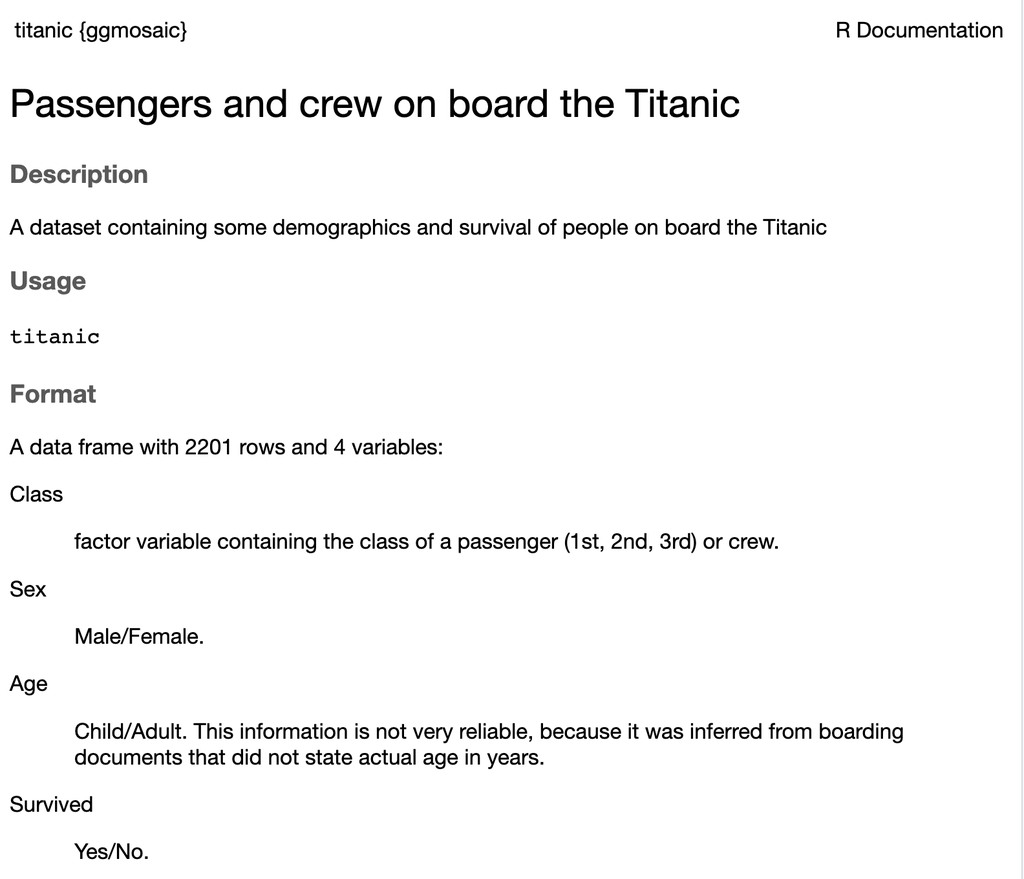

3. 数据集：diamonds {ggplot2}。提示：安装和加载包ggplot2, 然后运行data(diamonds)

   利用R完成下列要求,附上R代码及输出结果。

   3.1 对clarity和cut进行独立性检验。

   3.2 绘制马赛克图(Mosaic Plot)呈现clarity和cut的分布。

   3.3 对clarity和color进行独立性检验。

   3.4 绘制马赛克图(Mosaic Plot)呈现clarity和color的分布。

[figure not shown]